# periodic-bitmap

## 周期的bitmapの解析

ここでは周期的bitmapの解析を行います。

### パーシステント図の計算

このnotebookがあるディレクトリには `periodic-binary-image.png` というファイルがあります。これを解析してみましょう。

まず画像を表示させます。

```python
from IPython.display import display, Image
```

```python
%matplotlib inline
%load_ext autoreload
%autoreload 2
```

```
The autoreload extension is already loaded. To reload it, use:
  %reload_ext autoreload
```

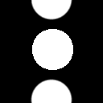

```python
display(Image("periodic-binary-image.png"))
```

上下に合わさると、白丸が出来ることが分かります。

imageioを使って画像を読み込みます

```python
import imageio
```

```python
image = imageio.v3.imread("periodic-binary-image.png", mode="L")
```

画像の画素値のヒストグラムを確認しておきます

```python
image.shape
```

```
(128, 128)
```

```python
import matplotlib.pyplot as plt
import numpy as np
```

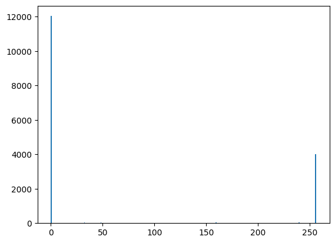

```python
plt.hist(np.ravel(image), range=(0,256), bins=256); None
```

ここでは黒い領域に注目するので、128より小さい領域を取り出します。

```python
bitmap = image < 128
```

初めは、binary-imageの時と同様に行います。

```python
import homcloud.interface as hc
```

```python
hc.PDList.from_bitmap_levelset(hc.distance_transform(bitmap, signed=True), save_to="bitmap.pdgm")
```

```
PDList(path=bitmap.pdgm)
```

以下のようにしてファイルを読み出すことができます。

```python
pdlist = hc.PDList("bitmap.pdgm")
```

## パーシステント図の可視化

次に計算結果の1次のパーシステント図、つまり穴構造を可視化しましょう。 上の計算で黒の領域に注目するようにしたので、白い穴構造に注目します。

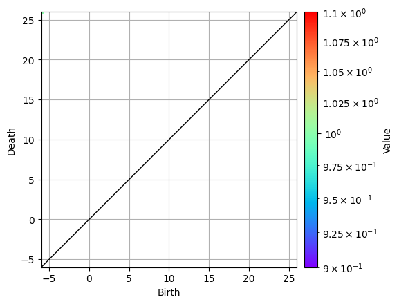

```python
pdlist.dth_diagram(1).histogram().plot(colorbar={"type":"log"})
```

上手く表示されるようにプロットの解像度を調整します。

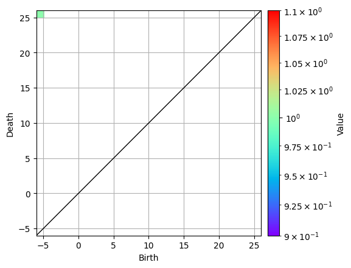

```python
pdlist.dth_diagram(1).histogram(x_bins=28).plot(colorbar={"type":"log"})
```

`x_bins=28`ヒストグラムの分割を28x28に指定します。 左上隅の緑の点が画像の中心の白穴を表しています。

これを画像に保存するには matplotlib の `savefig` を使います.このあたりもポイントクラウドの場合と同じです。

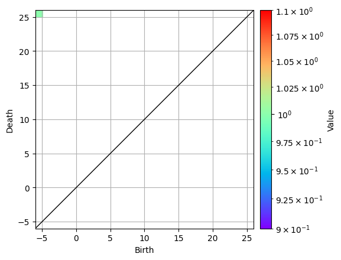

```python
pdlist.dth_diagram(1).histogram(x_bins=28).plot(colorbar={"type":"log"})
plt.savefig("bitmap-pd1.png")
```

Death pixelを見て穴の位置を確認します．

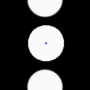

```python
death_pixel_image = hc.draw_birthdeath_pixels_2d(
    pdlist.dth_diagram(1).pairs(), image, draw_death=True
)
display(death_pixel_image)
```

次に周期的bitmapを計算します。

```python
hc.PDList.from_bitmap_levelset(hc.distance_transform(bitmap, signed=True, periodicity=[True, False]), periodicity=[True, False], save_to="periodic-bitmap.pdgm")
```

```
PDList(path=periodic-bitmap.pdgm)
```

```python
periodic_pdlist = hc.PDList("periodic-bitmap.pdgm")
```

ではプロットしてみます。

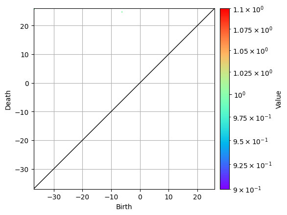

```python
periodic_pdlist.dth_diagram(1).histogram().plot(colorbar={"type":"log"})
```

拡大します

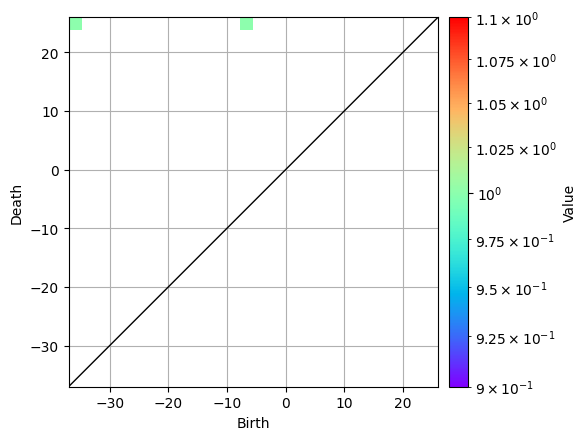

```python
periodic_pdlist.dth_diagram(1).histogram(x_bins=28).plot(colorbar={"type":"log"})
```

周期的でないものと比べると新しい穴構造が出来ていることがわかります、これが周期的に上下につなげたことにより生じた穴と対応しています。 最後にdeath pixelでこの2つの穴の位置を確認します．

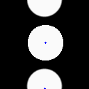

```python
death_pixel_image = hc.draw_birthdeath_pixels_2d(
    periodic_pdlist.dth_diagram(1).pairs(), image, draw_death=True
)
display(death_pixel_image)
```

以上で周期的bitmapの解析のチュートリアルは終わりです。